# SC417 - Introduction aux antennes

## TP - Conception et simulation d'une antenne patch

Objectifs : Concevoir et simuler une antenne patch rectangulaire pour une fréquence donnée.

1) La conception se fera à l’aide de formules analytiques classiquement utilisées pour ce type d’antenne très utilisée en pratique et simple à mettre en œuvre.

2) La simulation sera réalisée à l’aide d’un simulateur électromagnétique (ANSYS) permettant d’obtenir l’ensemble des informations caractérisant le fonctionnement de l’antenne.

**Ce notebook a pour but de traiter la première partie concernant la conception théorique de l'antenne.**

# 1 - Introduction

## Qu'est ce qu'une antenne patch?

*Définition (wikipédia) L’antenne planaire ou patch (en anglais) est une antenne plane dont l'élément rayonnant est une surface conductrice généralement carrée, séparée d'un plan réflecteur conducteur par une lame diélectrique. Sa réalisation ressemble à un circuit imprimé double face, substrat, et est donc favorable à une production industrielle.*

**Utilisation** Ce type d'antenne est très utilisé pour les fréquence supérieur à 1GHz. La forme de l'antenne peut être quelconque (généralement rectangulaire ou ronde).

**Fonctionnament** Nous pouvons comparer une antenne patch à une cavité résonnante. Si l'antenne est excité à la fréquence de résonnance, un champ est créé à l'intérieur de la cavité et va créer un fort courant à la surface du patch. Cela produit alors un champ rayonnant, une antenne.

**Avantages**

- très fine
- facile à fabriquer
- facile à "exciter" (coax, microruban etc..)
- facile à intégrer sur une circuit

**Inconvénients** (p10 et 11)

- faible bande-passante
- moins bonne efficiency que les autres antennes
- utilisable uniquement aux fréquence microwves
- ne supporte pas une puissance élevée

**Modes d'excitations** (p20 à 27)

- **Coaxiale**
- **Microruban**
- Proximité électromagnétique
- Gap coupled
- Aperture coupled Il y a un impact sur la méthode d'excitation choisie. Dans le cadre de notre TP cela sera étudier lors de la simulation sous Ansys.

**Adaptation de la ligne pour l'antenne** (p53 et 54)

# 2 - Calcul des valeurs géométriques de l'antenne patch

Nous allons maintenant suivre méthodiquement les différentes étapes afin de définir les différentes valeurs de notre antenne patch. Nous allons suivre les étapes décrites dans le schéma suivant:

1 définitions des entrées 2 définitions des équations et paramètres de sortie 3 Calcul des valeurs de sortie 4 tracé 5 Déduction des performances

### Déclaration des variables d'entrées

Dans cette première cellules, nous allons définir les bibliothèques python à utiliser. Ensuite nous allons définir les variables. Nos données d'entrées sont la permittivité $\epsilon_r$ et la hauteur $h$ du substrat utilisé, la fréquence d'utilisation $f_{10}$ et l'impédance $Z_0$

```python
#importation des bibliothèques
import numpy as np
import matplotlib.pyplot as plt
import matplotlib.patches as patches
%matplotlib inline
# vitesse de la lumière
c = 3*np.power(10,8)
# données du substrat
epsi_r = 2.33
h=0.001575 #en m
# fréquence d'utilisation
f10 = 1.575*np.power(10,9)
# Impédance
Z0 = 50
```

### Détermination des longueurs L et W

Nous utilisons l'expression suivante fin de déterminer L:

$f_{10}=\frac{c}{2\sqrt{\epsilon_r}}(\frac{1}{L+2\Delta L})$ soit $L=\frac{c}{2\sqrt{\epsilon_r}f_{10}}-2\Delta L$

Pour calculer L il nous faut alors déterminer $\Delta L$ avec l'expression suivante:

$\Delta L= 0.412h[\frac{(\epsilon_{reff}+0.3)(\frac{W}{h}+0.264)}{(\epsilon_{reff}-0.258)(\frac{W}{h}+0.8)}]$

Il nous faut également calculer la permittivité relative effective du milieu guidé:

$\epsilon_{reff}=\frac{\epsilon_{r}+1}{2}+\frac{\epsilon_{r}-1}{2}[1+12(\frac{h}{W})]^{-1/2}$

Il nous faut également $W$ qui est simplement: $W=1.5L$ soit $W=1.5\frac{c}{2\sqrt{\epsilon_r}f_{10}}-2\Delta L$

```python
# Delta L
delta_L_approximation=0.5*h
# Calcul de W
#W=1.5*(c/(2*np.sqrt(epsi_r)*f10))-2*delta_L_approximation
# permittivité effective
#epsi_reff=((epsi_r+1)/2)+((epsi_r-1)/2)*(1/np.sqrt(1+12*(h/W)))
# Calcul de delta_L
#delta_L=(0.412*h*(((epsi_reff+0.3)*((W/h)+0.264))/((epsi_reff-0.258)*((W/h)+0.8))))
# Calcul de L
#L = (c/(2*np.sqrt(epsi_reff)*f10))-2*delta_L

L = (c/(2*np.sqrt(epsi_r)*f10))-2*delta_L_approximation
W=1.5*L
print("L =",L, "m")
print("W =",W, "m")
```

```
L = 0.0608175506743 m
W = 0.0912263260115 m
```

### Détermination du point d'éxcitation

#### Pour calculer $x_0$ il faut utiliser plusieurs formules et calculer plusieurs paramètres en amont.

Calcul de $R_S=\sqrt{\frac{\omega \mu_0}{2\sigma}}$ avec $\sigma = 3.0 * 10^7 S/m$ conductivité du cuivre et $\mu_0 = 4\pi * 10^7$ et $w=2\pi f_{10}$

ERREUR SUR VALEUR DE mu_0 dans l'énoncé?

```python
#Calcul de Rs
mu_0_false=np.pi*4*np.power(10,7)
mu_0=np.pi*4*0.0000001
sigma=3*np.power(10,7)
omega=2*np.pi*f10
Rs=np.sqrt((omega*mu_0)/(2*sigma))
Rs_false=np.sqrt((omega*mu_0_false)/(2*sigma))
print("RS =",Rs)
print("RS =",Rs_false)
```

```
RS = 0.0143965861378
RS = 143965.861378
```

Calcul de $c_1=1-\frac{1}{\epsilon_r}+\frac{2/5}{\epsilon_r^2}$

```python
#Calcul de c1
c1=1-(1/epsi_r)+((2/5)/(np.power(epsi_r,2)))
print("c1 =",c1)
```

```
c1 = 0.644495201606
```

Calcul de $p=1+\frac{a_2}{10}(k_0W)^2+(a_2^2+2a_4)(\frac{3}{560})(k_0W)^4+c_2(\frac{1}{5})(k_0L)^2+a_2c_2(\frac{1}{70})(k_0W)^2(k_0L)^2$ avec $c_2=-0.0914153$ et $a_2=-0.16605$ et $a_4=0.00761$

on a $k_0=\frac{2\pi}{\lambda_0}$ avec $\lambda_0=\frac{c}{f_0}$

```python
# définition de p
# on définit d'abord les paramètres constants
c2=-0.0914153
a2=-0.16605
a4=0.00761
lambda_0 = c/f10
k0=(2*np.pi)/lambda_0
p=1+(a2/10)*np.power(k0*W,2)+(np.power(a2,2)+2*a4)*(3/560)*np.power(k0*W,4)+c2*(1/5)*np.power(k0*L,2)+a2*c2*(1/70)*np.power(k0*W,2)*np.power(k0*L,2)
print("p =",p)
```

```
p = 0.802749574573
```

Calcul de $e_{rhed}=\frac{1}{1+\frac{3}{4}\pi (k_0h)(\frac{1}{C_1})(1-\frac{1}{\epsilon_r})^3}$

```python
#Calcul de erhed
erhed=1/(1+(3/4)*np.pi*(k0*h)*(1/c1)*np.power(1-(1/epsi_r),3))
print("erhed =",erhed)
```

```
erhed = 0.965879052319
```

avec $\eta_0=376.73$ et $lq = 0.001$

```python
#Calcul de lq tan delta = 0.001
lq=0.001
#calcul de Redge
eta_0=376.73
Redge=(((4*eta_0)/np.pi)*(L/W)*(h/lambda_0))/(lq+(Rs/(np.pi*eta_0))*(1/(h/lambda_0))+(16/3)*((p*c1)/epsi_r)*(L/W)*(h/lambda_0)*(1/erhed))
print("Redge =",Redge)
```

```
Redge = 286.479267743
```

Enfin nous pouvons calculer $x_0$

$R=R_{inmax}=R_{edge}cos^2(\frac{\pi x_0}{L})$ avec $cos^2(x) = \frac{1+cos(x)}{2}$ on en déduit $x_0 = L\frac{cos^{-1}[\frac{2R}{R_{edge}}-1]}{2\pi}$

R est l'impédance vue par le cable coaxiale branché en $x_0,y_0$ On prend dans notre cas $R = Z_0=50 $

```python
#Calcul de x0
R=Z0
x0=L*((np.arccos((((2*R)/Redge)-1))/(2*np.pi)))
print("x0 =",x0,"m")
```

```
x0 = 0.0220653006832 m
```

La valeur de $y_0$ est simple à déterminer: $y_0=\frac{W}{2}$

```python
y0=W/2
print("y0 =",y0,"m")
```

```
y0 = 0.0456131630057 m
```

### Représentation graphique des résultats obtenues

```
L = 0.0608175506743
W = 0.0912263260115
X0 = 0.0220653006832 Y0 = 0.0456131630057
```

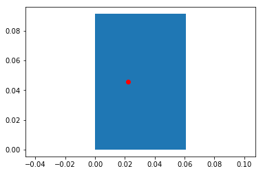

```python
# Dessine surface
fig, ax = plt.subplots(1,)
ax.set_xlim(0,5)
ax.set_ylim(0,5)
ax.add_patch(
    patches.Rectangle(
        (0, 0),   # (x,y)
        L,          # width
        W,          # height
    )
)
plt.axis('equal')
plt.show
ax.plot(x0, y0, 'or')

print("L =",L)
print("W =",W)
print("X0 =", x0, "Y0 =",y0)
```

### Directivité

$D=(\frac{3}{pc1})[\frac{\epsilon_r}{\epsilon_r+tan^2(k_1h)}](tanc^2(k_1h))$

avec $tanc^2(x)=\frac{tan(x)}{x}$ et $k_1=k_0\sqrt{\epsilon_r}$

```python
k1=k0*np.sqrt(epsi_r)
D=(3/(p*c1))*((epsi_r)/(epsi_r+np.power(np.tan(k1*h),2)))*(np.power((np.tan(k1*h)/(k1*h)),2))
# attention a vérifier!
print("D =" ,D, "->",10*np.log10(D), "dB")
```

```
D = 5.80723591677 -> 7.63969469441 dB
```

## Impédance

### Calcul de Xp

$X_p=\frac{\eta_0}{2\pi}(k_0h)[-\gamma+ln(\frac{2}{\sqrt{\epsilon_r}(k_0a)})]$

avec $\gamma=0.577216$ et $a=0.5mm$

```python
# Calcul de Xp
gamma=0.577216
a=0.0005
Xp=(eta_0/(2*np.pi))*(k0*h)*(-gamma+np.log((2)/(np.sqrt(epsi_r)*(k0*a))))
print("Xp = ",Xp, " Ohms (résultat du ppt Xp=11.1 Ohms)")
```

```
Xp =  11.8304567641  Ohms (résultat du ppt Xp=11.1 Ohms)
```

### Calcul de Q

$\frac{1}{Q}=\frac{1}{Q_d}+\frac{1}{Q_c}+\frac{1}{Q_{sp}}+\frac{1}{Q_{sw}}$

avec $Q_d=\frac{1}{tan\delta}$ et $Q_c=\frac{\eta_0}{2}\frac{k_0h}{R_s}$ et $Q—{sp}=\frac{3}{16}\frac{\epsilon_r}{pc_1}\frac{L}{W}\frac{1}{H/\lambda_0}$ et $Q_{sw}=Q_{sp}(\frac{e_{ehed}}{1-e_{ehed}})$

```python
# Calcul de Q
Qd=1/lq
Qc=(eta_0/2)*((k0*h)/Rs)
Qsp=(3/16)*(epsi_r/(p*c1))*(L/W)*(1/(h/lambda_0))
Qsw=Qsp*(erhed/(1-erhed))
Q=1/(1/Qd+1/Qc+1/Qsp+1/Qsw)
print("Q =",Q," (résultat du ppt Q=56.8)")
```

```
Q = 56.56636351  (résultat du ppt Q=56.8)
```

### Résultat de l'impédance

$Z_{in}=jX_p+\frac{R}{1+jQ(\frac{f}{f_0}-\frac{f_0}{f})}$

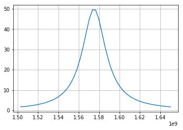

```python
# Calcul de l'impédance pour f= 1.5GHz à 1.65Ghz
f=np.linspace(1500000000, 1650000000, num=50)
Zin_real=np.linspace(1500000000,1650000000, num=50)
for i in range(1,50) :
    Zin=np.complex(0,Xp)+(R/((1+(np.complex(0,Q*((f[i]/f10)-(f10/f[i])))))))
    Zin_real[i]=np.real(Zin)
plt.plot(f[1:50],Zin_real[1:50])
plt.grid()
plt.show()

#print(Zin)
```

### Représentation graphique dynamiques

```
<function __main__.update>
```

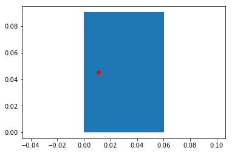

```python
from ipywidgets import *
#importation des bibliothèques
import numpy as np
import matplotlib.pyplot as plt
import matplotlib.patches as patches
%matplotlib inline
def update( h=0.2125,epsi_r = 2.33 ,f10 = 1.575*np.power(10,9)):
    # vitesse de la lumière
    c = 3*np.power(10,8)
    # données du substrat
    eta_0=376.73

    # fréquence d'utilisation

    # Impédance
    Z0 = 50
    # Delta L
    delta_L_approximation=0.005*h
    L = (c/(2*np.sqrt(epsi_r)*f10))-2*delta_L_approximation
    W=1.5*L
    # définition de p
    # on définit d'abord les paramètres constants
    c2=-0.0914153
    a2=-0.16605
    a4=0.00761
    lambda_0 = c/f10
    k0=(2*np.pi)/lambda_0
    p=1+(a2/10)*np.power(k0*W,2)+(np.power(a2,2)+2*a4)*(3/560)*np.power(k0*W,4)+c2*(1/5)*np.power(k0*L,2)+a2*c2*(1/70)*np.power(k0*W,2)*np.power(k0*L,2)
    #Calcul de c1
    c1=1-(1/epsi_r)+((2/5)/(np.power(epsi_r,2)))
    #Calcul de erhed
    erhed=1/(1+(3/4)*np.pi*(k0*h)*(1/c1)*np.power(1-(1/epsi_r),3))
    #Calcul de Rs
    #mu_0=np.pi*4*np.power(10,7)
    mu_0=np.pi*4
    #sigma=3*np.power(10,7)
    sigma=59.6*np.power(10,6)
    omega=2*np.pi*f10
    Rs=np.sqrt((omega*mu_0)/(2*sigma))
    #Calcul de lq
    lq=0
    #calcul de Redge
    #eta_0=376.73
    #Redge=(((4*eta_0)/np.pi)*(L/W)*(h/lambda_0))/(lq+(Rs/(np.pi*eta_0))*(1/(h/lambda_0))+(16/3)*((p*c1)/epsi_r)*(L/W)*(h/lambda_0)*(1/erhed))
    Redge=(((4*eta_0)/np.pi)*(L/W)*(h/lambda_0))/(lq+(Rs/(np.pi*eta_0))*(1/(h/lambda_0))+(16/3)*((p*c1)/epsi_r)*(L/W)*(h/lambda_0)*(1/erhed))
    #Calcul de x
    R=Z0
    x0=L*((np.arccos((((2*R)/Redge)-1))/(2*np.pi)))
    y0=W/2
    # Dessine surface
    fig, ax = plt.subplots(1,)
    ax.set_xlim(0,5)
    ax.set_ylim(0,5)
    ax.add_patch(
    patches.Rectangle(
        (0, 0),   # (x,y)
        L,          # width
        W,          # height
    )
    )
    plt.axis('equal')
    plt.draw
    ax.plot(x0, y0, 'or')
interact(update)
```

```python
def update( f10=1575000000):
    # Calcul de l'impédance pour f= 1.5GHz à 1.65Ghz
    f=np.linspace(1500000000, 1650000000, num=50)
    Zin_real=np.linspace(1500000000,1650000000, num=50)
    for i in range(1,50) :
        Zin=np.complex(0,Xp)+(R/((1+(np.complex(0,Q*((f[i]/f10)-(f10/f[i])))))))
        Zin_real[i]=np.real(Zin)
    plt.plot(f[1:50],Zin_real[1:50])
    plt.grid()
    plt.show()
interact(update)
#print(Zin)
```

[output not shown]

```
<function __main__.update>
```